# FLIBM Manual

# 1 Description

FLIBM is a individual-based model (IBM) framework for the simulation of fish or invertibrate populations, and should provide a flexible structure that allows for modification given the population under study. Presently, the IBM describes processes affecting life history in terms of length (e.g. growth, mortality, maturity). This faciltates the generation of length-frequency data (FLD), which is typically used in many data-poor assessment approaches. Nevertheless, an individual’s age is also followed in order to be able to record both length- and age-based summary statistics in the form of `FLStock` objects (see FLR project: http://www.flr-project.org/). Following the FLR framework allows for integration in other FLR-related recources.

The main sequence of processes in the IBM operating model are as follows:

1. *update* - Updates the states of individuals at the beginning of a time step (e.g. mortality rates, maturity).
2. *reproduce* - Creates new individuals based on spawning schedule and stock recruitment relationship.
3. *die* - Determines individuals that die, either naturally or from fishing.
4. *record* - Records the state of the population in FLStock objects (e.g. numbers, mean weight by age and length, mortality rates, etc.).
5. *remove* - Removes dead individuals.
6. *grow* - Grows individuals according to growth function, resulting in changes to length and weight variables.

Generally, the model should be run at a sufficiently high number of interannual time steps (default = 12, i.e. monthly) to produce realistic behaviour and summary indices.

# 2 Setup

The FLIBM imports the package `FLCore` and recommends `ggplotFL` for use of summary plotting functions.

```r
library(FLIBM)
library(FLCore)
library(ggplotFL)
library(data.table)
set.seed(42) # for reproducibility
```

## 2.1 Creating new FLIBM object

The `create.FLIBM` function is used to intialize an FLIBM object. As with `FLStock` and `FLQuant` objects, one defines 6 data dimensions:

1. *age* or *length* - Classes of age or length
2. *year* - Calendar year
3. *unit* - Division of the population (e.g. by sex)
4. *season* - Temporal strata shorter than year
5. *area* - Spatial stratification
6. *iter* - Replicates

Other arguments for `create.FLIBM` are related to units of numbers (`n.units`) and weights (`wt.units`).

```r
stk <- create.FLIBM(
  length = 0:85, age = 0:6,
  year = ac(2000:2009),
  season = ac(1:12),
  n.units = "1e3", wt.units = "kg"
)
```

## 2.2 FLIBM class structure

The basic structure of an FLIBM class is as follows:

```r
summary(stk)
```

```
          Length Class      Mode
growth        2  -none-     list
rec           5  -none-     list
m             1  -none-     list
harvest       2  -none-     list
n.units       1  -none-     character
wt.units      1  -none-     character
make.inds     1  -none-     function
inds         14  data.table list
stock.l       1  FLStock    S4
stock.a       1  FLStock    S4
length.a    840  FLQuant    numeric
age.l     10320  FLQuant    numeric
```

## 2.3 Editing FLIBM objects

### 2.3.1 Controlling objects

The main objects types that are manipulated by the user are the *controlling* objects.

```r
stk$rec$params['rmax'] <- 1e4
```

### 2.3.2 Recording objects

By default, FLStock objects are set up to have fbar ranges spanning the full range of dimension 1 (`age` and `length`).

```r
range(stk$stock.a); range(stk$stock.l)
```

```
      min       max plusgroup   minyear   maxyear   minfbar   maxfbar
        0         6         6      2000      2009         0         6
```

```
      min       max plusgroup   minyear   maxyear   minfbar   maxfbar
        0        85        85      2000      2009         0        85
```

For plotting and further FLR-related functionality, it is advised to adjust these as appropriate, *e.g.*:

```r
range(stk$stock.a)[c("minfbar", "maxfbar")] <- c(1,3)
range(stk$stock.a)
```

```
      min       max plusgroup   minyear   maxyear   minfbar   maxfbar
        0         6         6      2000      2009         1         3
```

## 2.4 Spin-up

A spin-up of the ìnds`is also possible. At the moment this function uses the control information from the first simulation year.

```r
stk <- spinup.FLIBM(obj = stk, nyearsslope = 10)
```

```
year = 1 | ssb = 2.072 | trend = 1
year = 2 | ssb = 123.339 | trend = 1
year = 3 | ssb = 851.973 | trend = 1
year = 4 | ssb = 1667.527 | trend = 1
year = 5 | ssb = 1927.63 | trend = 1
year = 6 | ssb = 1917.891 | trend = 1
year = 7 | ssb = 2061.884 | trend = 1
year = 8 | ssb = 2129.647 | trend = 1
year = 9 | ssb = 2086.101 | trend = 1
year = 10 | ssb = 2084.67 | trend = 1
year = 11 | ssb = 2036.07 | trend = 1
year = 12 | ssb = 2055.573 | trend = 1
year = 13 | ssb = 2038.006 | trend = 1
year = 14 | ssb = 2107.572 | trend = 0
```

Viewing the `$inds`

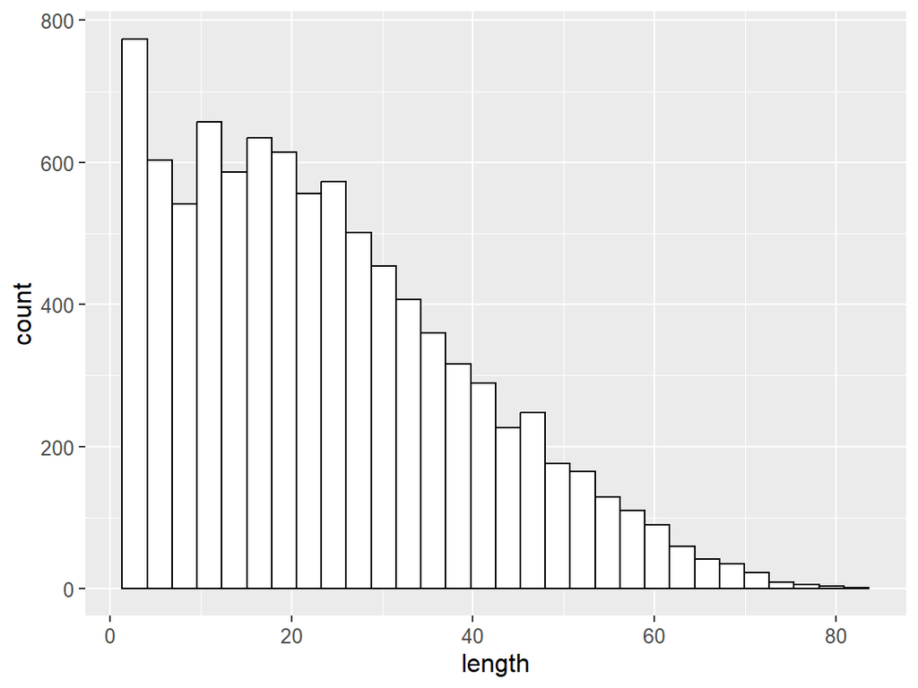

```r
ggplot(stk$inds, aes(x = length)) +
  theme(text = element_text(size=12)) +
  geom_histogram(color = "black", fill = "white",
    na.rm=TRUE)
```

# 3 Advancing the stock forward in time

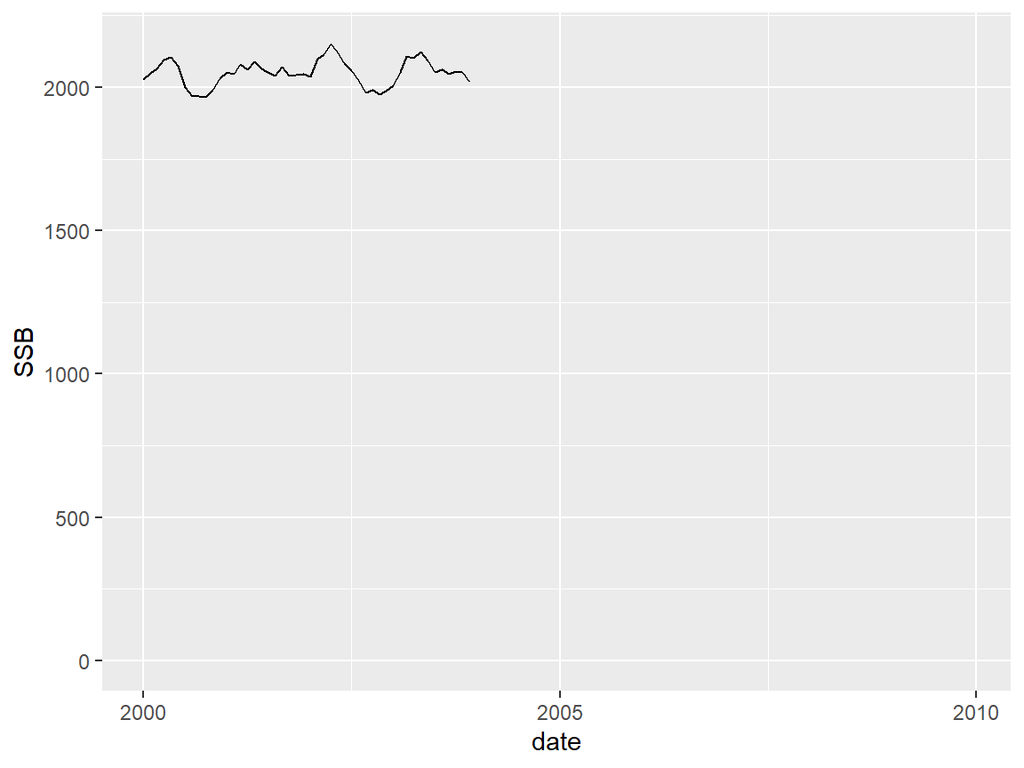

```r
stk <- adv.FLIBM(stk, years = ac(2000:2003), monitor = FALSE)

# plot ssb
df <- as.data.frame(stock.n(stk$stock.a)
  * stock.wt(stk$stock.a) * mat(stk$stock.a))
df$date <- as.Date(paste(as.numeric(df$year),
  as.numeric(as.character(df$season)), "01", sep = "-"),
  format = "%Y-%m-%d")
df <- aggregate(x = df$data, by = list(date = df$date),
  FUN = sum, na.rm=TRUE)
df$x[df$x == 0] <- NA

p <- ggplot(data = df, aes(x = date, y = x)) +
  geom_line() +
  scale_y_continuous(limits = c(0,NA)) +
  labs(y = "SSB")

print(p)
```

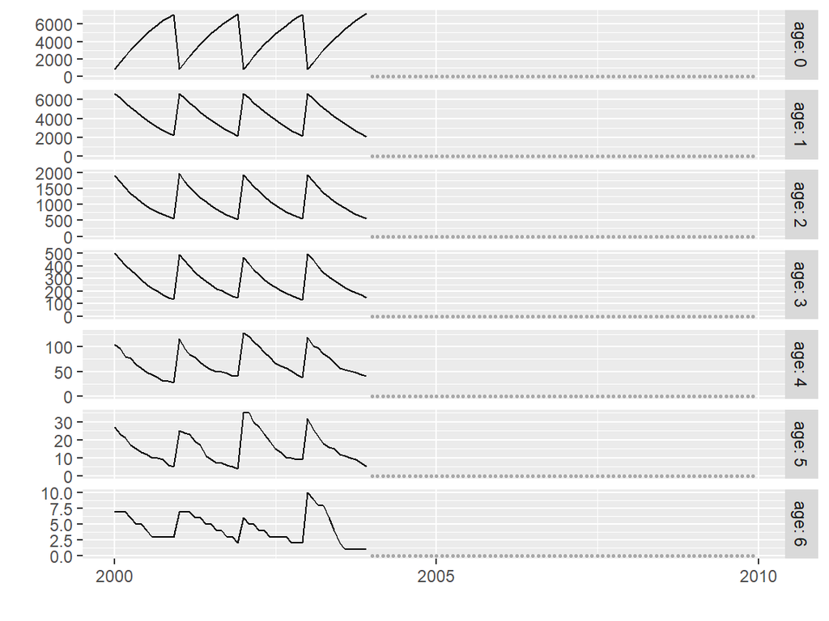

```r
# plot stock numbers
plot(stk$stock.a@stock.n)
```

Summary stats

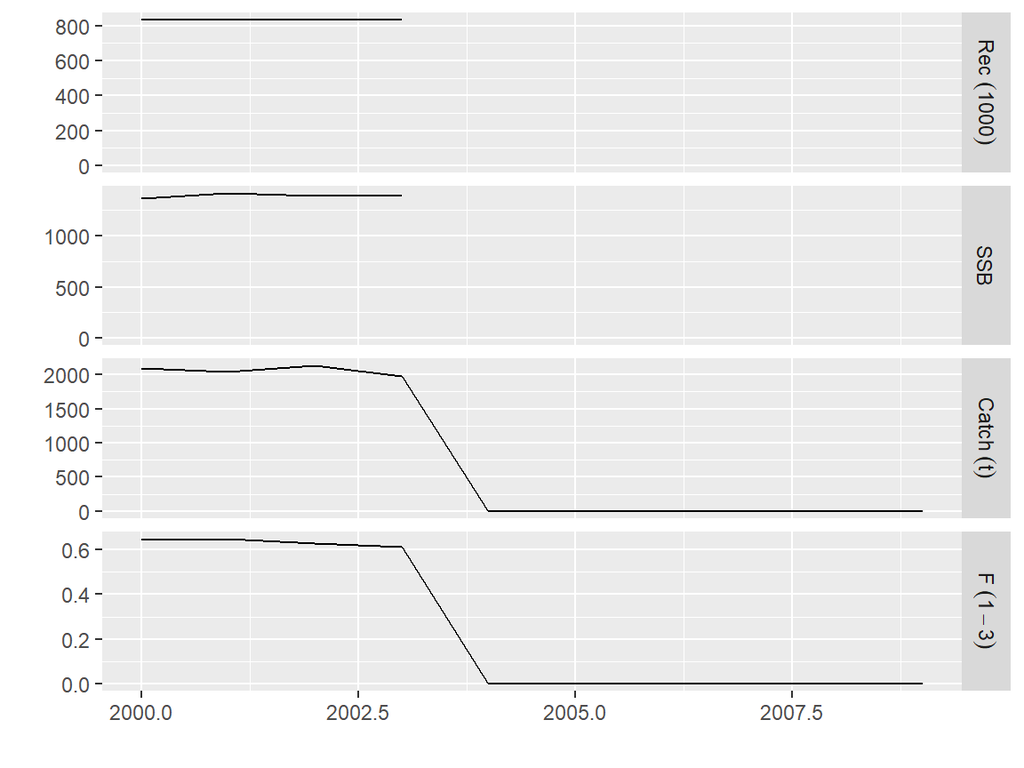

```r
plot(simplifySeason(stk))
```

# 4 Indicators and plotting

## 4.1 LFQ

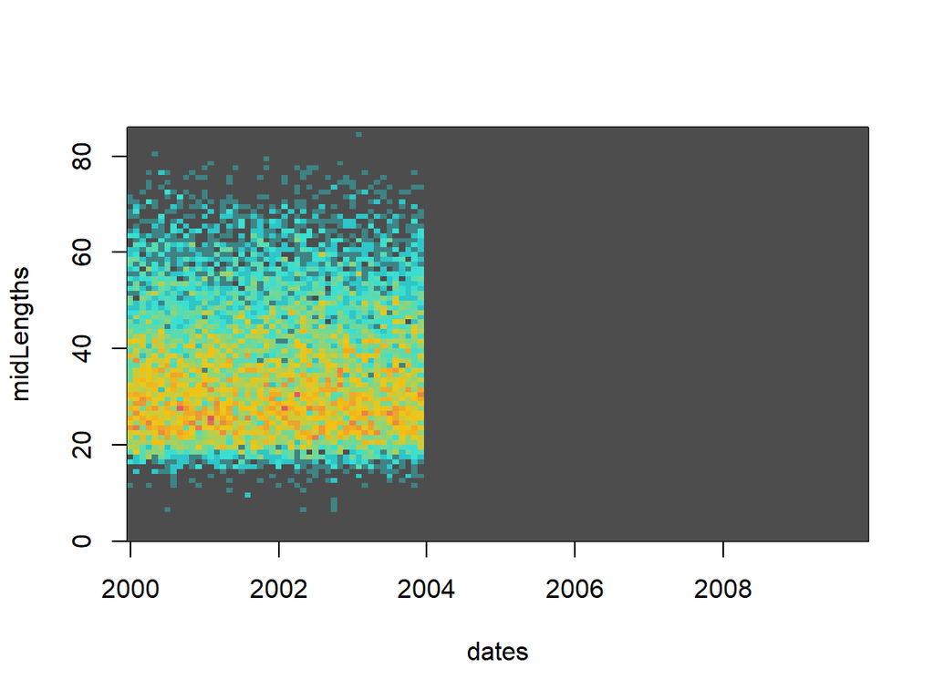

```r
# plot length-frequency
lfq <- flquant2lfq(stk$stock.l@catch.n)
pal <- colorRampPalette(c("grey30",5,7,2), bias=2)
with(lfq, image(x=dates, y=midLengths, z=t(catch), col=pal(100)))
```

## 4.2 Mortality

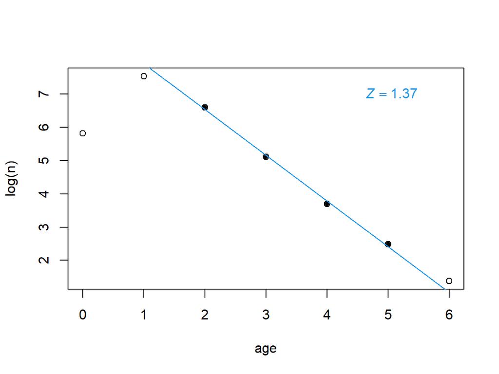

```r
df <- data.frame(
  age = as.numeric(dimnames(stk$stock.a@catch.n)$age),
  n = c(apply(window(stk$stock.a@catch.n, start=2003, end=2003),
    1, sum, na.rm=TRUE)))

plot(log(n) ~ age, df)
fit <- lm(log(n) ~ age, df, subset = age %in% 2:5)
points(log(n) ~ age, df, subset = age %in% 2:5, pch=20)
abline(fit, col=4)
usr <- par()$usr
text(0.9*usr[2], 0.9*usr[4],
  labels = bquote(italic(Z)==.(sprintf("%.2f",-round(coef(fit)[2], 2)))),
  pos = 2, col=4)
```

## 4.3 Other: F, maturity, mean Lm etc…

To come…

length at maturity

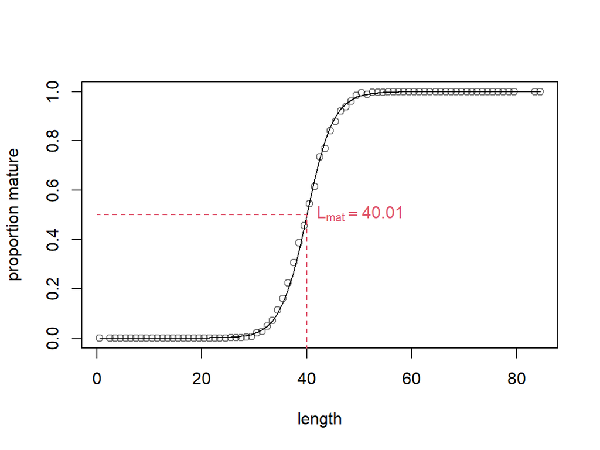

```r
df <- as.data.frame(apply(stk$stock.l@mat[,"2003"],
  1, mean, na.rm=TRUE))
names(df)[1] <- "length"
df <- na.omit(df)
df$length <- df$length+0.5 # bin mid-length
fit <- glm(data ~ length, data = df,
  family = binomial(link = "logit"))
pred <- predict(fit, se.fit=TRUE)
df <- cbind(df, pred)
# Calculate confidence intervals
std <- qnorm(0.95 / 2 + 0.5)
df$ymin <- fit$family$linkinv(df$fit - std * df$se.fit)
df$ymax <- fit$family$linkinv(df$fit + std * df$se.fit)
df$fit <- fit$family$linkinv(df$fit)  # Rescale to 0-1

plot(data ~ length, data = df, t="n", ylab="proportion mature")
points(data ~ length, data = df, col=adjustcolor(1, 0.5))
lines(fit ~ length, df, col=1)
lrPerc <- function(alpha, beta, p) (log(p/(1-p))-alpha)/beta
L50 <- lrPerc(alpha=coef(fit)[1], beta=coef(fit)[2], p=0.5)
lines(x=c(L50,L50,0), y=c(-100,0.5,0.5), lty=2, col=2)
text(x=L50, y=0.5, labels = bquote(L[mat]==.(round(L50,2))), pos=4, col=2 )
```

Mean length in catch:

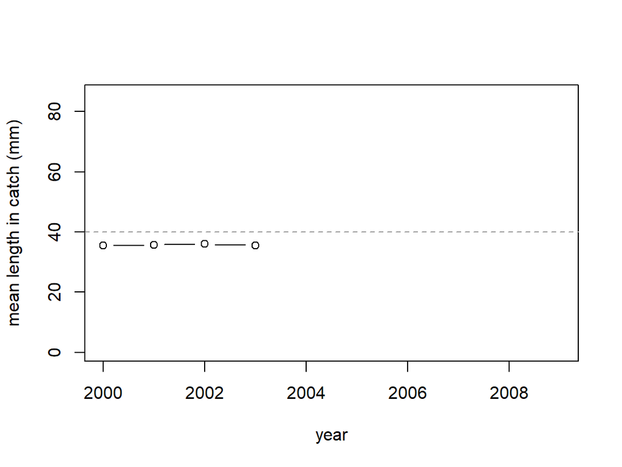

```r
df <- expand.grid(
  length = as.numeric(dimnames(stk$stock.l@catch.n)[[1]])+0.5,
  year = as.numeric(dimnames(stk$stock.l@catch.n)[[2]])
)
tmp <- apply(stk$stock.l@catch.n, 1:2, sum, na.rm=TRUE)
df$n = c(tmp)
df$lengthProd <- df$length * df$n

agg1 <- aggregate(cbind(lengthProd, n) ~ year, data = df,
  FUN = sum, na.rm=TRUE)
agg1$meanLength <- agg1$lengthProd / agg1$n
plot(meanLength ~ year, agg1, t="b", ylim=range(df$length),
  ylab = "mean length in catch (mm)")
abline(h = L50, lty=2, col=8)
```

Yearly fishing mortality:

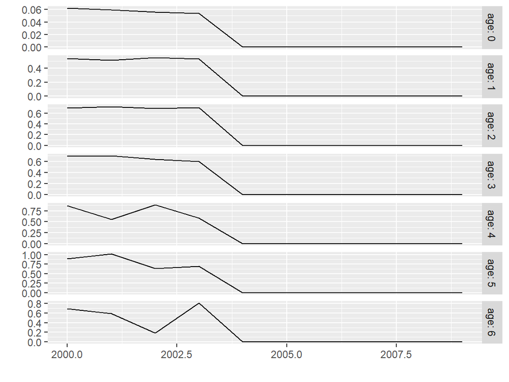

```r
df <- apply(stk$stock.a@harvest, 1:2, sum, na.rm=TRUE)
plot(df)
```

# 5 Advanced

## 5.1 Simulating fishery development over time

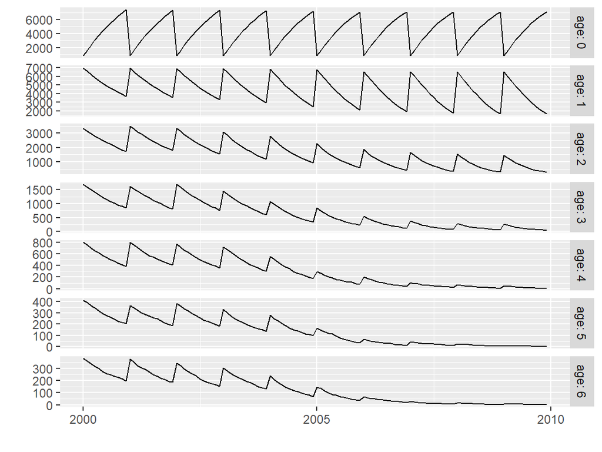

```r
year <- as.numeric(dimnames(stk$stock.a@stock.n)[[2]])
steepness <- 1
FMmax <- 0.7*1.5
FMs <- FMmax / (1 + exp(-steepness * (year - 2004) ))

# spin-up with starting F
stk$harvest$params$FM <- FMs[1]
stk <- spinup.FLIBM(obj = stk, nyearsslope = 5, monitor = FALSE)
for(y in seq(year)){
  stk$harvest$params$FM <- FMs[y]
  stk <- adv.FLIBM(obj = stk, year = ac(year[y]), monitor = FALSE)
}

# plot stock numbers
plot(stk$stock.a@stock.n)
```

View biomass and spawning stock biomass development by year:

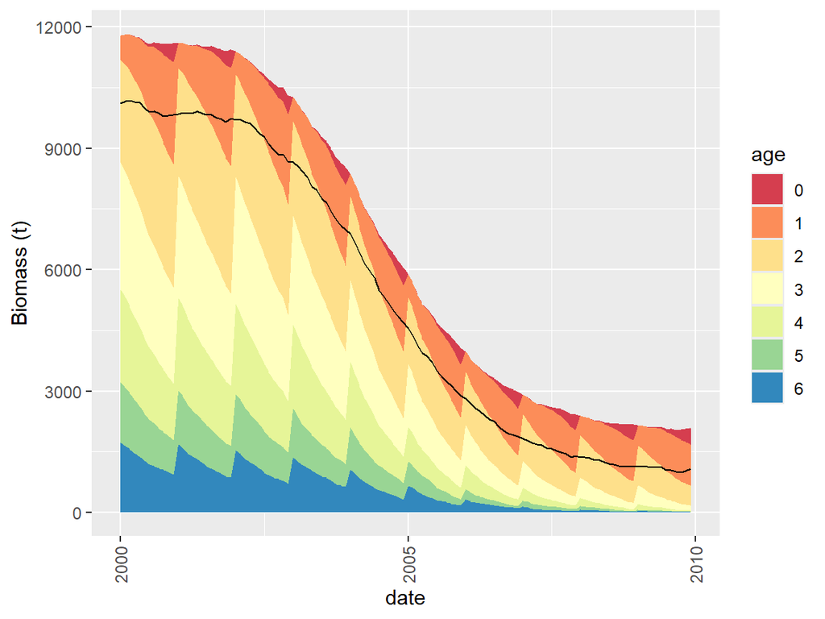

```r
# B
dat1 <- as.data.frame(stock.n(stk$stock.a) * stock.wt(stk$stock.a),
  date=TRUE)
dat1$age <- factor(dat1$age)

# SSB
dat2 <- as.data.frame(stock.n(stk$stock.a) * stock.wt(stk$stock.a) *
    mat(stk$stock.a), date=TRUE)
dat2 <- aggregate(x = dat2$data, by = list(date = dat2$date),
  FUN = sum, na.rm=TRUE)
dat2$age <- factor("0")

p <- ggplot2::ggplot(data = dat1,
  aes(x=date, y=data, fill=age, group=age)) +
  theme_set(theme_gray(base_size = 9)) +
  geom_area(position = 'stack') +
  scale_fill_brewer(palette="Spectral") +
  geom_line(data = dat2, aes(x=date, y=x) ) +
  ylab("Biomass (t)") +
  theme(axis.text.x=element_text(angle = 90, hjust=1, vjust = 0.5))
  print(p)
```

Mean length in catch:

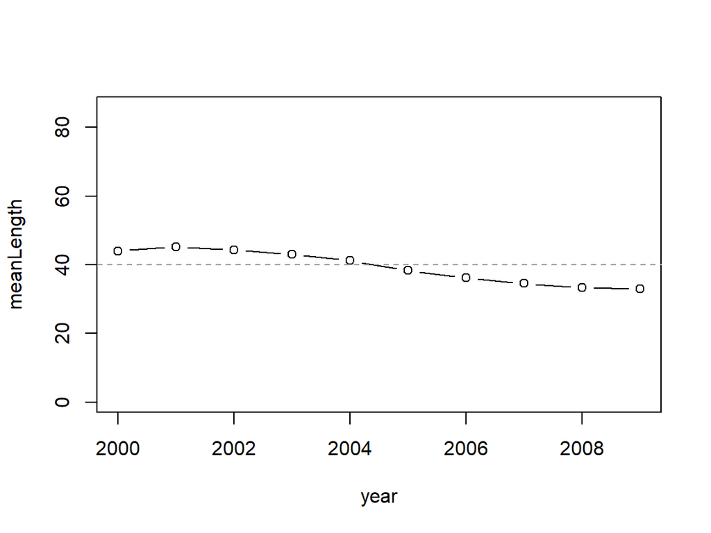

Fishing mortality:

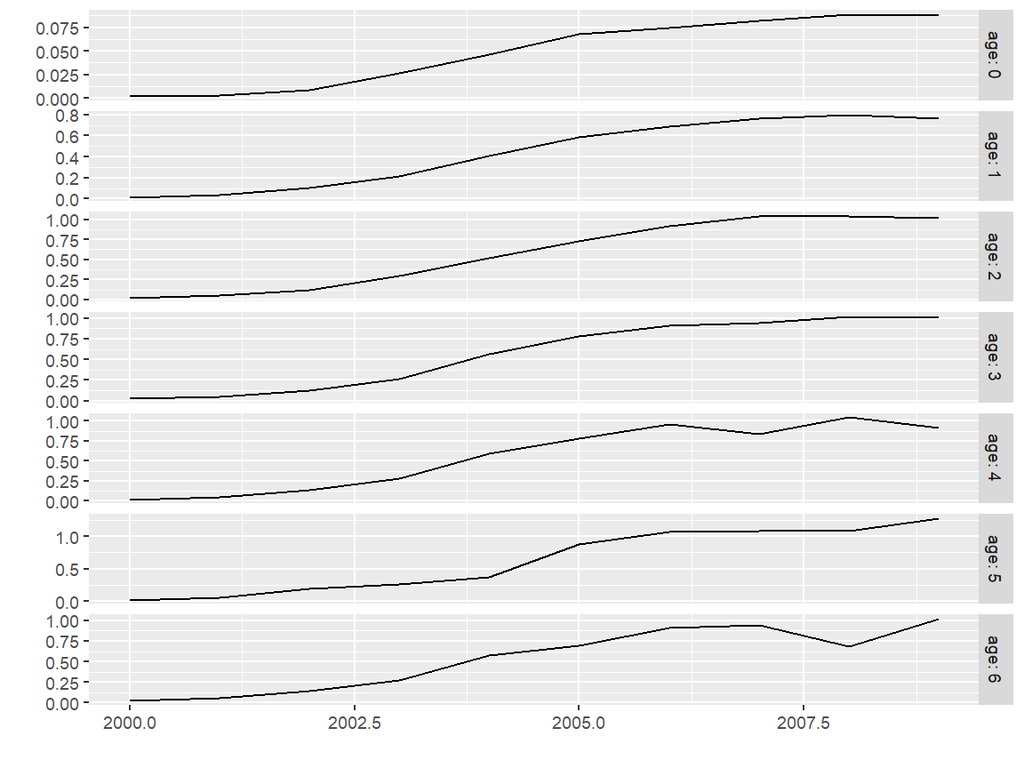

```r
df <- apply(stk$stock.a@harvest, 1:2, sum, na.rm=TRUE)
plot(df)
```

## 5.2 Seasonal growth and recruitment

More to come…

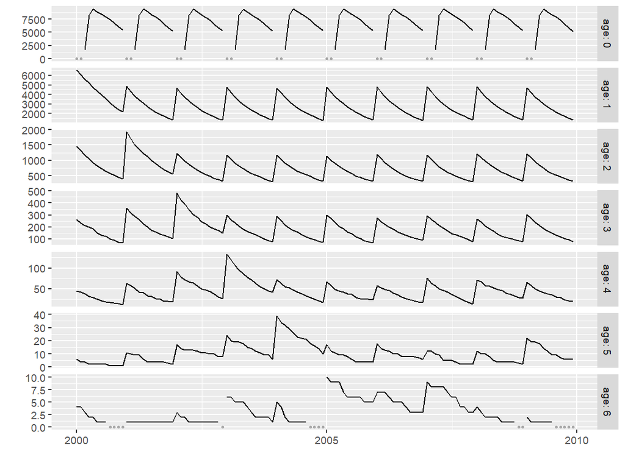

```r
# pulsed recruitment
stk$rec$params$season_wt[] <- 0
stk$rec$params$season_wt[3:5] <- c(0.25, 1, 0.25)

# seasonal growth oscillation
stk$growth$params['C'] <- 0.75

# fishing mortality
stk$harvest$params['FM'] <- 0.7

# spinup and advance
stk <- adv.FLIBM(stk, years = ac(2000:2009), monitor = FALSE)

# plot stock numbers
plot(stk$stock.a@stock.n)
```

The function `simplifySeason` can be used to collapse the season dimension, resulting in the more typical yearly FLStock object. The following example also removes the age zero group to define age = 1 as recruits. Without this change, recruits are not plotted since no individuals of age = 0 are alive at the start of the year. This object can be direcly plotted, providing a clear visualization of the main stock attributed (recruitment, SSB, Catch, fishing mortality).

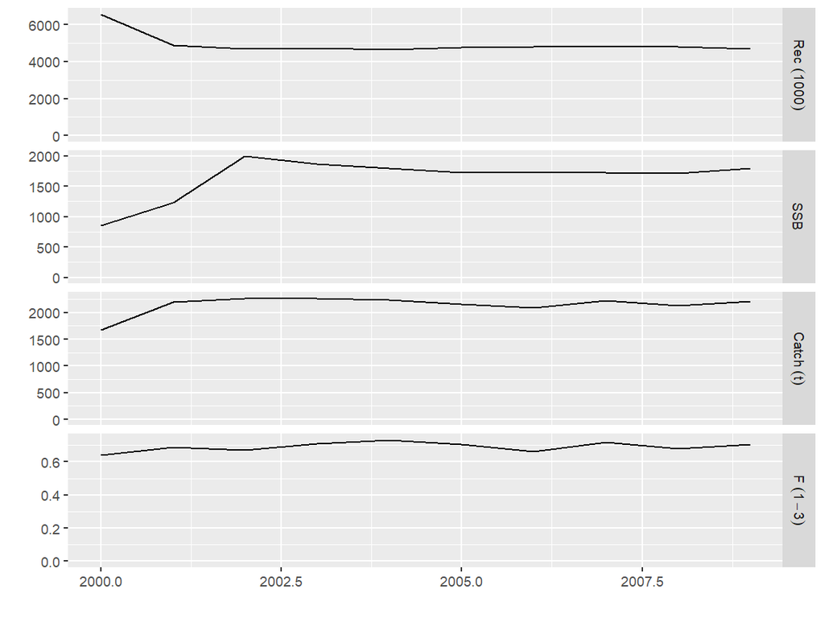

```r
# summary stats
tmp <- simplifySeason(stk)
tmp <- tmp[ac(1:range(tmp)["max"]),] # remove age=0 group
plot(tmp)
```

LFQ

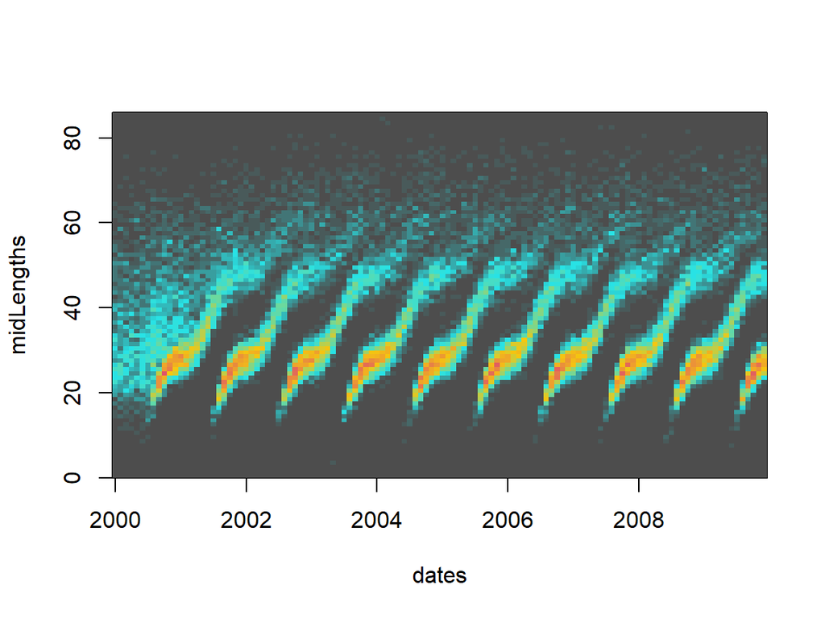

```r
# plot length-frequency
lfq <- flquant2lfq(stk$stock.l@catch.n)
pal <- colorRampPalette(c("grey30",5,7,2), bias=2)
with(lfq, image(x=dates, y=midLengths, z=t(catch), col=pal(100)))
```

## 5.3 Recruitment variation

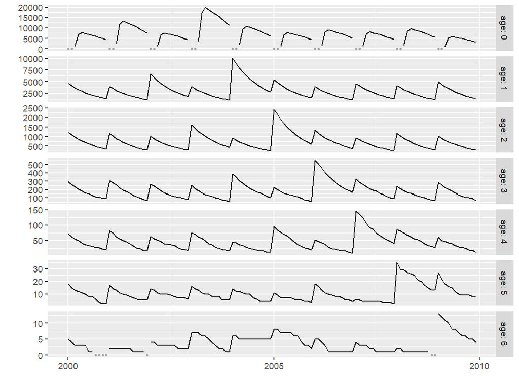

```r
# add log-normal noise to rec covar (one value per year)
stk$rec$covar[] <- rlnorm(n = dim(stk$rec$covar)[2], meanlog = 0, sdlog = 0.5)

stk <- adv.FLIBM(stk, years = ac(2000:2009), monitor = FALSE)

# plot stock numbers
plot(stk$stock.a@stock.n)
```

LFQ

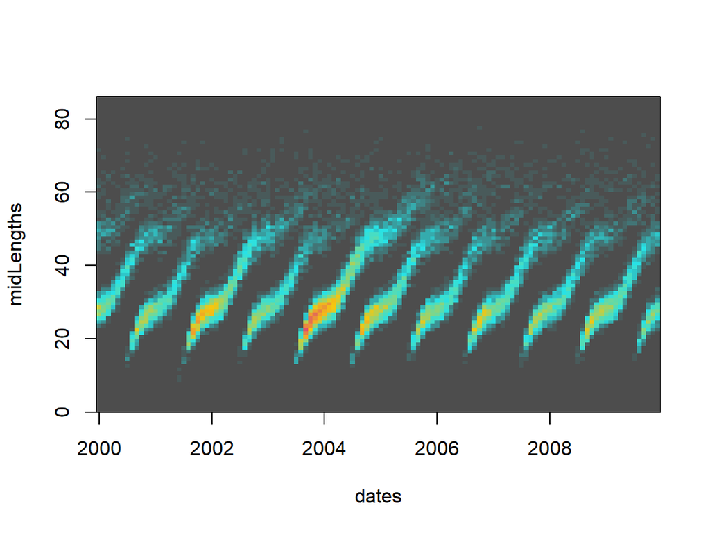

```r
# plot length-frequency
lfq <- flquant2lfq(stk$stock.l@catch.n)
pal <- colorRampPalette(c("grey30",5,7,2), bias=2)
with(lfq, image(x=dates, y=midLengths, z=t(catch), col=pal(100)))
```

# 6 References

L. T. Kell, I. Mosqueira, P. Grosjean, J-M. Fromentin, D. Garcia, R. Hillary, E. Jardim, S. Mardle, M. A. Pastoors, J. J. Poos, F. Scott, R. D. Scott; FLR: an open-source framework for the evaluation and development of management strategies. *ICES J Mar Sci* 2007; 64 (4): 640-646. doi: 10.1093/icesjms/fsm012.

# 7 More information

- You can submit bug reports, questions or suggestions on this tutorial at https://github.com/marchtaylor/FLIBM/issues.
- Alternatively, send a pull request to https://github.com/marchtaylor/FLIBM/.

## 7.1 Software Versions

- R version 4.4.2 (2024-10-31 ucrt)
- data.table: 1.16.2
- FLCore: 2.6.20.9102
- FLIBM: 0.3.3
- ggplotFL: 2.7.0.9133
- TropFishR: 1.6.5
- **Compiled**: 2025-Jan-16

## 7.2 License

This document is licensed under the [Creative Commons Attribution-ShareAlike 4.0 International](https://creativecommons.org/licenses/by-sa/4.0) license.

## 7.3 Author information

**Marc Taylor**. Thünen Institute of Sea Fisheries, Marine Living Resources Unit, Herwigstraße 31, 27572 Bremerhaven, Germany. https://www.thuenen.de/en/sf/